# GridION cDNA sequence annotation Pinfish workflow

Stéphane Plaisance [analysis], Caroline Van Damme [data production] VIB - Nucleomics Core, nucleomics@vib.be

Report created: 2019-08-30

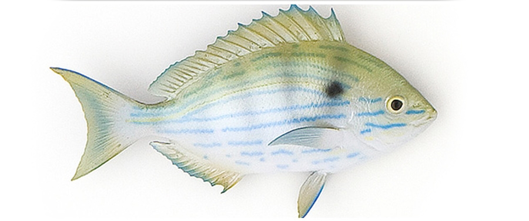

# 1 Aim

A cDNA library was prepared from Saccharomyces cerevisiae (S288c) total RNA using the **‘Teloprime v2 kit’** (https://www.lexogen.com/teloprime-full-length-cdna-amplification/). mRNA was processed and amplified to lead to a nanopore cDNA library loaded on a single GridION flow-cell. RNA QC and run metrics are not reported here but were all in specs (CVD).

This sequencing experiment aims at defining the yield and analyse the content of a cDNA run in order to evaluate whether this approach is applicable to RNA expression studies and potentially differential transcriptome analysis. The sample used for this pilot experiment was prepared in large quantities after growth on a rich medium. A second pilot experiment will be needed to evaluate the reproducibility of such sequencing applied to several replicates and two different growth conditions.

# 2 GridION Transcriptome data processing workflow

Best quality read data was produced by re-basecalling the raw ONT data with Guppy (version 3.0.6) in high accuracy calling mode (hac).

The **‘Pinfish analysis pipeline’** selects reads which have both primer sequences expected from the library prep and cuts the found fragments out to produce a high quality data subset using **‘Pychopper’** (https://github.com/nanoporetech/pychopper).

All selected reads are aligned to the reference genome with **‘minimap2’** (Li 2018) to find the corresponding loci. The obtained mapping data is then used to cluster different gene regions and obtain spliced variants with documented exon usage. The clusters are corrected using the long read mapping data and **‘racon’** (Vaser et al. 2017) then classified against the reference transcriptome models and statistics are returned to report expected and novel entities (Morgan, Lawrence, and Anders 2018).

The table below reports the counts of the different entities found with the sequencing dataset.

Summary statistics for the cDNA data processed before and after PyChopper filtering

|  | RawData | Pychopper |
| --- | --- | --- |
| reads | 3,847,604 | 2,210,342 |
| mbs | 7,333 | 2,868 |
| min | 64 | 205 |
| max | 52816 | 47538 |
| mean | 1905.9 | 1297.6 |
| median | 1349 | 1191 |
| qval | 20 | 20.5 |
| gc | 41.6 | 39.4 |
| n50 | 2392 | 1541 |
| l50 | 750009 | 680289 |
| n90 | 922 | 733 |
| l90 | 2708628 | 1708385 |

The summary statistics displayed in the table above include observational metrics including the number of reads, information on the longest, shortest and mean sequence read lengths and other information that includes GC content, N50 and N90 read lengths. The first result column describes the sequence characteristics of the raw sequence collection. The second column describes the sequences following the **`pychopper`** analysis.

**`pychopper`** selects for sequence reads that contain the appropriate adapter sequences at both ends of the sequence (sub)read. These adapter sequences are also used to orientate the sequences into the correct stranded orientation. Running **`pychopper`** on your sequence collection will reduce the total number of reads but will qualitatively increase the utility of the library for isoform discovery. The table above should be reviewed to see how the starting sequence library has been transformed.

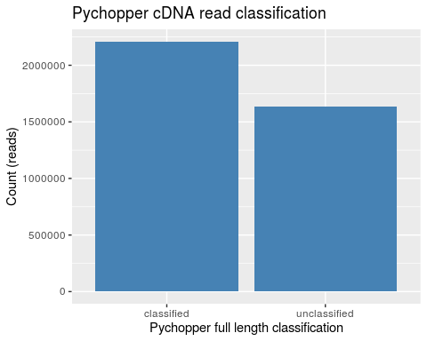

The figure above shows a the distribution of reads that have been called as either full length (classified) or not being full length (unclassified). If too many reads have been removed this could be an indication of problems during library preparation (wrong choice of the primer sequences given to Pychopper or technical issue during library prep).

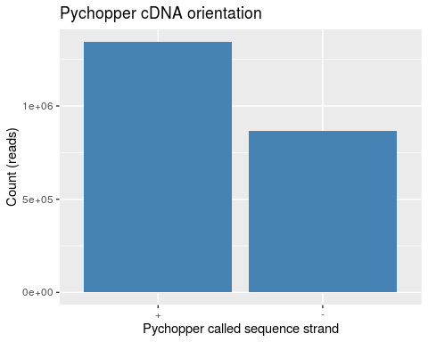

The figure above shows the distribution of Pychopper classifications for sequence reads oriented in the (+) or (-) direction.

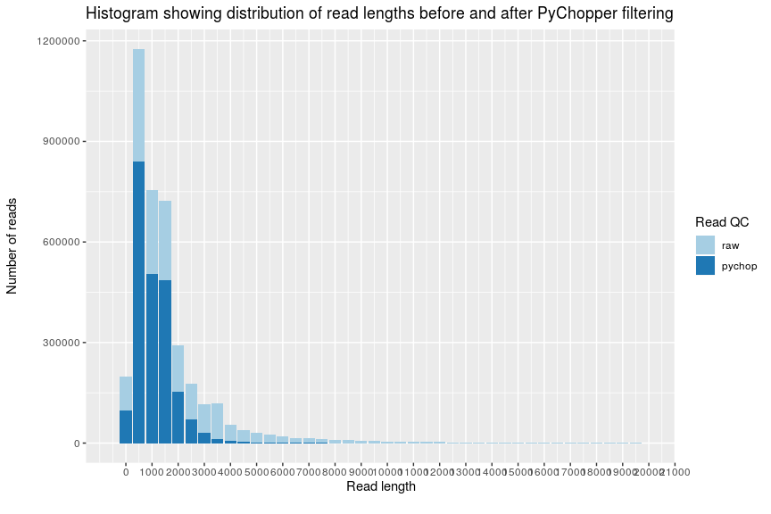

The figure above shows a histogram of the sequence read length distribution before and after the **`pychopper`** analysis. A global concordance is observed with reduction of longest reads cleaved by Pychopper at the level of the second primer (potential chimera during the run)

# 3 Pinfish clustering and polishing

The **`pinfish analysis pipeline`** is run by the **`snakemake`** workflow management software and the results from the analysis are stored in the folder: `Analysis/Pinfish/`

The **`pinfish`** workflow is described fully at its [github page](https://github.com/nanoporetech/pinfish) and at the [pipeline-pinfish-analysis page](https://github.com/nanoporetech/pipeline-pinfish-analysis). The working folder contains a number of intermediate files; the key result files include:

- **`polished_transcripts_collapsed.gff`** is a gff format annotation file that describes the gene transcripts identified following clustering, sequence correction and transcript collapse within the **`pinfish`** workflow
- **`corrected_transcriptome_polished_collapsed.fas`** is a fasta format sequence file that provides the DNA sequence for the identified transcripts. This is based on the **`gff`** annotations calculated and the reference genome provided. These fasta sequences are produced using the **`gffread`** software

# 4 Exon size & read depth from the clustered data

The clustered & collapsed results were parsed from the file ‘clustered_transcripts_collapsed.gff’ and the data used to produce the feature abundance vs size scatter plot below.

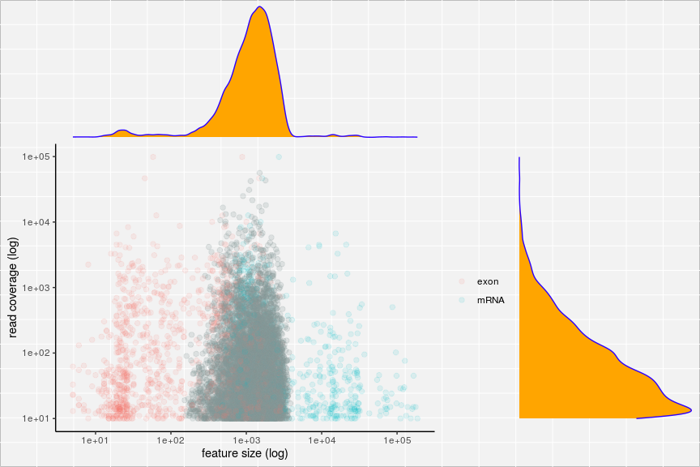

# 5 Expressed genes and expression levels from the raw data

Based on the Full BAM data and the genome coordinate of all exons (current reference genome: **R64-1-1.97**), we computed how many of the reference exons had coverage and counted the corresponding genes (keeping the average exon coverage as final coverage value). In this section, we made use of the tool **‘mosdepth’** (https://github.com/brentp/mosdepth) and some R magic.

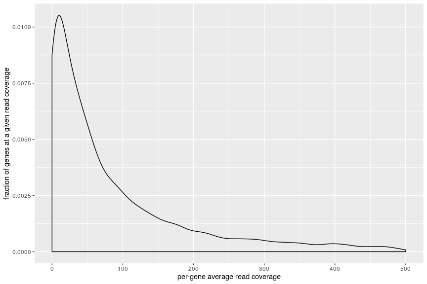

REM: the plot was truncated at 500 to hide the very long tail of highly expressed genes

The full distribution of expressed genes is shown next with the cumulative sum of the read coverage across all 7127 genes ordered from the least to the most expressed

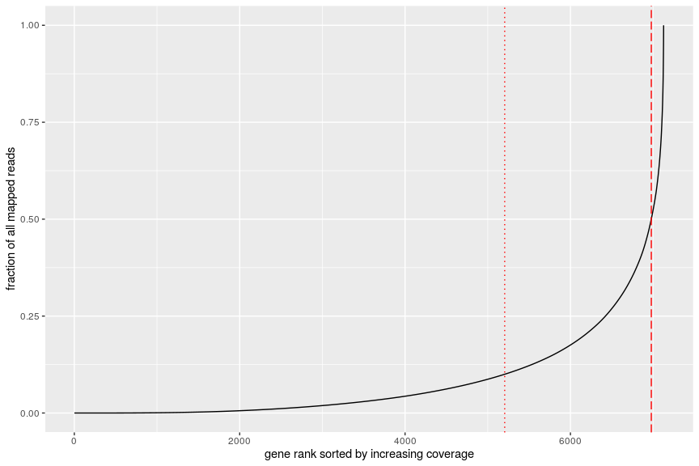

REM: the dotted line divides the coverage data in 10% for the left genes and 90% for the right genes while the dashed line shows the N50 (as many reads mapping to both sides).

The top N genes (from the right of the plot) contribute to X% of all reads

- 1922 most expressed genes => 90% of the reads
- 149 most expressed genes => 50% of the reads
- 20 most expressed genes => 25% of the reads
- 3 most expressed genes => 10% of the reads

The next table reports the top100 most expressed genes based on coverage values (right of the curve).

Top 100 expressed genes

| gene | chr | from | to | avg_cvg | read_fraction |
| --- | --- | --- | --- | --- | --- |
| YCL025C | III | 76017 | 77919 | 2997.620 | 0.13% |
| YJL166W | X | 106433 | 106718 | 3014.220 | 0.13% |
| YMR107W | XIII | 483013 | 483361 | 3051.660 | 0.14% |
| YOL040C | XV | 253148 | 253577 | 3056.430 | 0.14% |
| YEL009C | V | 138917 | 139763 | 3060.540 | 0.14% |
| YCL043C | III | 48652 | 50221 | 3084.270 | 0.14% |
| YOL039W | XV | 254296 | 254617 | 3180.600 | 0.14% |
| YJR073C | X | 572314 | 572935 | 3195.230 | 0.14% |
| YER088C | V | 333175 | 335188 | 3264.990 | 0.15% |
| YOR369C | XV | 1028193 | 1028625 | 3385.440 | 0.15% |
| YOR167C | XV | 648803 | 649007 | 3400.300 | 0.15% |
| YLR150W | XII | 440466 | 441288 | 3518.160 | 0.16% |
| YLR390W-A | XII | 903723 | 904440 | 3521.670 | 0.16% |
| YPR149W | XVI | 829917 | 830439 | 3585.260 | 0.16% |
| YDL130W-A | IV | 229170 | 229431 | 3647.430 | 0.16% |
| YNL241C | XIV | 196425 | 197943 | 3745.950 | 0.17% |
| YIL018W | IX | 316767 | 317932 | 3762.060 | 0.17% |
| YLR037C | XII | 222684 | 223059 | 3791.550 | 0.17% |
| YKL163W | XI | 144400 | 145378 | 3795.870 | 0.17% |
| YOR230W | XV | 770799 | 772113 | 3823.420 | 0.17% |
| YCR005C | III | 120945 | 122328 | 3837.250 | 0.17% |
| YAL038W | I | 71785 | 73288 | 3851.330 | 0.17% |
| YAL037C-B | I | 72325 | 73300 | 3864.780 | 0.17% |
| YLR178C | XII | 513161 | 513821 | 3936.450 | 0.18% |
| YLR258W | XII | 660715 | 662833 | 3978.790 | 0.18% |
| YPL272C | XVI | 26610 | 28164 | 3997.420 | 0.18% |
| YER150W | V | 468369 | 468816 | 4005.750 | 0.18% |
| YDL184C | IV | 130406 | 130484 | 4028.410 | 0.18% |
| YMR246W | XIII | 759806 | 761891 | 4042.700 | 0.18% |
| YAL062W | I | 31566 | 32940 | 4249.640 | 0.19% |

[output cut: 70 more lines]

# 6 Functional enrichment results from the Top100 expressed genes

The biological functions carried by the top 100 expressed genes were identified using *YeastMine* as part of the **InterMine** suite (Smith et al. 2012) (http://intermine.org/).

Top10 Miner-enriched GO categoried for the Top100 genes

[output not shown]

Miner-enriched pathways for the Top100 genes

| identifier | description | pValue | count | populationAnnotationCount |
| --- | --- | --- | --- | --- |
| GLYCOLYSIS | glycolysis | 4.292041785180737E-8 | 9 | 14 |
| GLUCONEO-PWY | gluconeogenesis | 7.504209742140523E-6 | 8 | 17 |

REM: The results above are hopefully representative of the culture medium and growth conditions applied to that sample. Better enrichment results would be obtained for differential expression betwen two conditions which we do not have here for that single sample.

# 7 Transcript Isoform concordance with the public annotations

The GffCompare methods provide a collection of tools that can be used to look for overlapping and novel features within and between genome annotation **`GFF`** files. The cluster and polished transcript annotations from **`pinfish`** are compared to the reference genome annotation. Each provided transcript is analysed to define if it novel (absent from the reference database), identical to a known transcript or similar to a known transcript..

**`GffCompare`** is run during the **`Snakemake`** process (Köster and Rahmann 2012). The method is run using the specified GFF genome annotation provided in the config file (`Saccharomyces_cerevisiae.R64-1-1.97.gtf`) and with the following configuration parameters

- **`-r`** specifies reference genome
- **`-R`** causes GffCompare to ignore reference transcripts that are not overlapped by any transcript in input GFF
- **`-M`** discard (ignore) single-exon transfrags and reference transcripts
- **`-C`** Discard the “contained” transfrags from the .combined.gtf output. By default, without this option, GffCompare writes in that file isoforms that were found to be fully contained/covered (with the same compatible intron structure)
- **`-K`** do NOT discard any redundant transfrag matching a reference

```
# gffcompare v0.11.2 | Command line was:
#gffcompare -r ReferenceData/Saccharomyces_cerevisiae.R64-1-1.97.gtf -R -M -C -K -o Analysis/GffCompare/nanopore Analysis/Pinfish/polished_transcripts_collapsed.gff
#

#= Summary for dataset: Analysis/Pinfish/polished_transcripts_collapsed.gff
#     Query mRNAs :     562 in     333 loci  (562 multi-exon transcripts)
#            (68 multi-transcript loci, ~1.7 transcripts per locus)
# Reference mRNAs :     218 in     218 loci  (218 multi-exon)
# Super-loci w/ reference transcripts:      215
#-----------------| Sensitivity | Precision  |
        Base level:    99.8     |    29.0    |
        Exon level:    63.1     |    28.5    |
      Intron level:    99.6     |    39.4    |
Intron chain level:    98.6     |    38.3    |
  Transcript level:    98.6     |    38.3    |
       Locus level:    98.6     |    64.0    |

     Matching intron chains:     215
       Matching transcripts:     215
              Matching loci:     215

          Missed exons:       0/444 (  0.0%)
           Novel exons:     535/1030    ( 51.9%)
        Missed introns:       0/226 (  0.0%)
         Novel introns:     303/571 ( 53.1%)
           Missed loci:       0/218 (  0.0%)
            Novel loci:     118/333 ( 35.4%)

 Total union super-loci across all input datasets: 333
561 out of 562 consensus transcripts written in Analysis/GffCompare/nanopore.combined.gtf (1 discarded as redundant)
```

The output above is from the **`GffCompare`** summary statistics. This describes the number of transcripts that were identified within the **`Pinfish`** analysis that are non-redundant and are overlapping with the provided reference annotation. Sensitivity and precision of annotation are compared with the reference. This output also provides information on the novelty of transcribed features. The formulae below describe the calculations for sensitivity and precision using true positives (TP), false positives (FP), true negatives (TN) and false negatives (FN).

Sensitivity = $TP/(TP+FN)$

Precision = $TP/(TP+FP)$

Values from the summary above were fed to the wub script ‘plot_gffcmp_stats.py’ to produce a plot shown next.

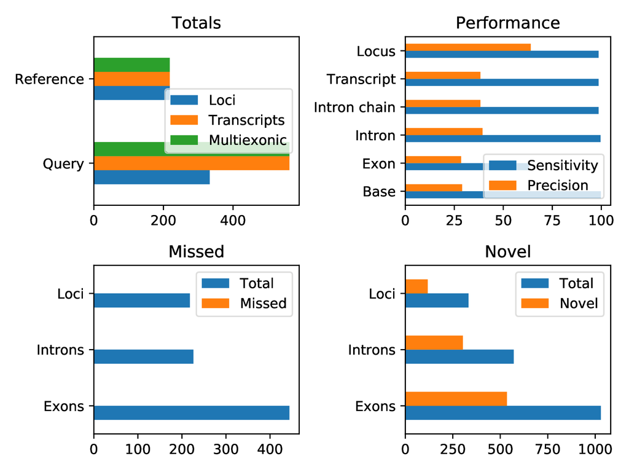

The analysis here only considers the reference genes that are partially or completely covered by **`Pinfish`** transcripts. The sensitivity will be determined by the number of starting cDNA sequence reads and the diversity of gene expression that was represented within the starting cDNA collection.

The **`GffCompare`** software classifies transcripts within its output files into classes that include (“=”, “u”, “c”) and others. These define how a transcript can be best described relative to the provided reference annotation.

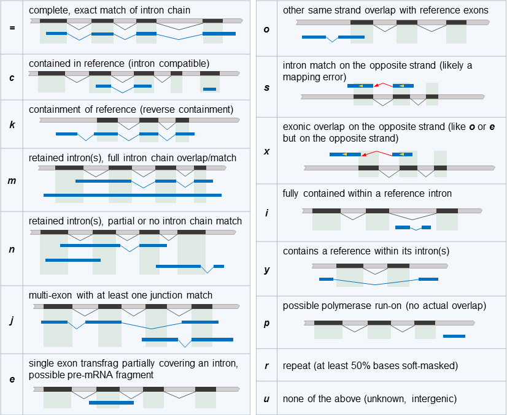

The figure above is from the **`GffCompare`** software webpages at John Hopkins University. This figure describes the different codes and provides cartoons illustrating the differences with canonical genes.

Summary statistics for the isoforms contrasted to the reference annotation are provided in the **`GffCompare/nanopore.tracking`** results file. These **`GffCompare`** codes can be plotted as a histogram.

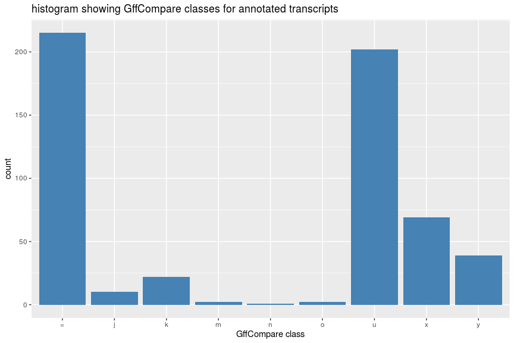

The histogram in the figure above shows the distribution of **`GffCompare`** annotated transcripts. There are **215** transcripts assigned code **`=`** or corresponding to an exact match with an annotated gene. **202** transcripts are undefined in the provided genome annotation GFF file. These transcripts could represent novel genes. The other codes together account for **25.8** **%** of the sequence reads and represent potentially novel isoforms with a variety of missing exons, retained introns and more complex multi-exon events.

GffCompare finally collapses transcribed-fragments (`transfrags`) into the single longest transcript that shares the same patterns of intron boundaries to produce a non-redundant set of transcripts.

A number of canonical transcripts (**=: complete exact match of intron chain**) are found when comparing to the public reference annotation.

Table summarising the first 20 of 215 transcripts identified by the Pinfish that correspond to GffCompare class “=”

| Chr | Pipeline | Feature | Start | Stop | Strand | Interval | Exons |
| --- | --- | --- | --- | --- | --- | --- | --- |
| I | pinfish | transcript | 87259 | 87857 | + | 598 | 2 |
| I | pinfish | transcript | 142029 | 143380 | + | 1351 | 2 |
| II | pinfish | transcript | 110674 | 111288 | + | 614 | 2 |
| II | pinfish | transcript | 125038 | 126182 | + | 1144 | 2 |
| II | pinfish | transcript | 168398 | 169552 | + | 1154 | 2 |
| II | pinfish | transcript | 170581 | 171169 | + | 588 | 2 |
| II | pinfish | transcript | 332783 | 334013 | + | 1230 | 2 |
| II | pinfish | transcript | 392947 | 395368 | + | 2421 | 2 |
| II | pinfish | transcript | 462117 | 462743 | + | 626 | 3 |
| II | pinfish | transcript | 604482 | 605574 | + | 1092 | 2 |
| II | pinfish | transcript | 606205 | 607253 | + | 1048 | 2 |
| II | pinfish | transcript | 653324 | 655430 | + | 2106 | 2 |
| II | pinfish | transcript | 46432 | 47188 | - | 756 | 2 |
| II | pinfish | transcript | 59710 | 60757 | - | 1047 | 2 |
| II | pinfish | transcript | 109962 | 110567 | - | 605 | 2 |
| II | pinfish | transcript | 142011 | 142900 | - | 889 | 2 |
| II | pinfish | transcript | 185927 | 186515 | - | 588 | 2 |
| II | pinfish | transcript | 365870 | 366625 | - | 755 | 2 |
| II | pinfish | transcript | 406459 | 407246 | - | 787 | 2 |
| II | pinfish | transcript | 414062 | 415283 | - | 1221 | 2 |

```
## The corresponding GTF data was stored in 'Analysis/GffCompare/class_=_nanopore.combined.gtf'
```

The table above shows the transcripts that were identified as class ‘=’. The columns presented show the chromosome on which the transcript has been identified, the nature of the transcript annotation and coordinates that include the start and stop coordinates, the strand on which the transcript has been annotated and the number of exons the transcript contains.

Other transcripts appear as novel (**u: potential novel transcripts**)

Table summarising the first 20 of 201 transcripts identified by the Pinfish that correspond to GffCompare class “u”

| Chr | Pipeline | Feature | Start | Stop | Strand | Interval | Exons |
| --- | --- | --- | --- | --- | --- | --- | --- |
| I | pinfish | transcript | 23704 | 33020 | + | 9316 | 2 |
| I | pinfish | transcript | 92852 | 101305 | + | 8453 | 2 |
| I | pinfish | transcript | 92853 | 101301 | + | 8448 | 2 |
| I | pinfish | transcript | 92895 | 101298 | + | 8403 | 2 |
| I | pinfish | transcript | 152106 | 169021 | - | 16915 | 2 |
| II | pinfish | transcript | 45613 | 46521 | + | 908 | 2 |
| II | pinfish | transcript | 380136 | 382843 | + | 2707 | 2 |
| II | pinfish | transcript | 490822 | 492970 | + | 2148 | 2 |
| II | pinfish | transcript | 490822 | 499554 | + | 8732 | 2 |
| II | pinfish | transcript | 691908 | 694621 | + | 2713 | 2 |
| II | pinfish | transcript | 744843 | 774686 | + | 29843 | 2 |
| II | pinfish | transcript | 761211 | 774686 | + | 13475 | 2 |
| II | pinfish | transcript | 761212 | 774686 | + | 13474 | 2 |
| II | pinfish | transcript | 768202 | 774686 | + | 6484 | 2 |
| II | pinfish | transcript | 773846 | 774686 | + | 840 | 2 |
| II | pinfish | transcript | 29816 | 36234 | - | 6418 | 2 |
| II | pinfish | transcript | 88107 | 89463 | - | 1356 | 3 |
| II | pinfish | transcript | 88109 | 101173 | - | 13064 | 2 |
| II | pinfish | transcript | 88126 | 101168 | - | 13042 | 2 |
| II | pinfish | transcript | 88414 | 89501 | - | 1087 | 2 |

```
## The corresponding GTF data was stored in 'Analysis/GffCompare/class_u_nanopore.combined.gtf'
```

Finally, a number of ‘**j: multi exon with at least one junction match**’ transcripts appear which may represent alternative splice of gnown genes.

Table summarising the 10 transcripts identified by the Pinfish that correspond to GffCompare class “j”

| Chr | Pipeline | Feature | Start | Stop | Strand | Interval | Exons |
| --- | --- | --- | --- | --- | --- | --- | --- |
| III | pinfish | transcript | 293823 | 294322 | + | 499 | 3 |
| III | pinfish | transcript | 293823 | 294342 | + | 519 | 3 |
| IV | pinfish | transcript | 337458 | 338139 | + | 681 | 2 |
| IV | pinfish | transcript | 253936 | 255186 | - | 1250 | 2 |
| V | pinfish | transcript | 307608 | 308197 | + | 589 | 3 |
| VI | pinfish | transcript | 75113 | 76554 | + | 1441 | 2 |
| VIII | pinfish | transcript | 297288 | 298636 | - | 1348 | 2 |
| VIII | pinfish | transcript | 297301 | 298635 | - | 1334 | 2 |
| VIII | pinfish | transcript | 497418 | 498890 | - | 1472 | 2 |
| XI | pinfish | transcript | 154960 | 158374 | + | 3414 | 2 |

```
## The corresponding GTF data was stored in 'Analysis/GffCompare/class_j_nanopore.combined.gtf'
```

Many of the non-canonical trascripts are probably alternative isoforms which have been misclassified and would require manual inspection and reclassification. Future version(s) of the current software are expected to improve the classification, in part by better clipping of the raw data prior to clustering but manual curation is probably teh best way to get final data from this type of analysis.

# 8 IGV visual inspection of the results

The Integrative Genomics Viewer (**`IGV`**) is a tool for the visualization of genomics data. The software provides functionality for the display of sequence mapping data from BAM files that can subsequently be overlaid with “tracks” of information that can include depth-of-coverage for mapping data and gene annotations.

**`IGV`** can be started from the command line by using the command `igv.sh`.

We recommend using **`IGV`** (*Integrative Genomics Viewer (Igv)* 2018) to display the raw and processed data in the context of the public reference. The command below will open the **`IGV`** browser to the display the main data from this analysis.

```bash
# on linux, IGV is called by igv.sh
# and bash variables below derived from the config.yaml values
# getting yaml to bash variables can easily be done with parse_yaml from https://gist.github.com/pkuczynski/8665367

parse_yaml ()
{
    local prefix=$2;
    local s='[[:space:]]*' w='[a-zA-Z0-9_]*' fs=$(echo @|tr @ '\034');
    sed -ne "s|^\($s\)\($w\)$s:$s\"\(.*\)\"$s\$|\1$fs\2$fs\3|p" -e "s|^\($s\)\($w\)$s:$s\(.*\)$s\$|\1$fs\2$fs\3|p" $1 | awk -F$fs '{
      indent = length($1)/2;
      vname[indent] = $2;
      for (i in vname) {if (i > indent) {delete vname[i]}}
      if (length($3) > 0) {
         vn=""; for (i=0; i<indent; i++) {vn=(vn)(vname[i])("_")}
         printf("%s%s%s=\"%s\"\n", "'$prefix'",vn, $2, $3);
      }
   }'
}

eval $(parse_yaml config.yaml)

cmd="igv.sh -g ./ReferenceData/$(basename ${genome_fasta%.gz}) \
./Analysis/Minimap2/$(basename ${raw_fastq}).bam,\
./Analysis/Minimap2/polished_reads_aln_sorted.bam,\
./ReferenceData/$(basename ${genome_annot%.gz}),\
./Analysis/Pinfish/polished_transcripts.gff,\
./Analysis/GffCompare/nanopore.combined.gtf,\
./Analysis/GffCompare/class_=_nanopore.combined.gtf,\
./Analysis/GffCompare/class_u_nanopore.combined.gtf,\
./Analysis/MosDepth/gene_coverage.igv"

echo "# running ${cmd}"
eval ${cmd}
```

REM: the next picture is indicative and may not reflect the current experiment

[figure not shown]

The obtained IGV session contains from top to bottom:

- the reference genome
- the average coverage computed with MosDepth
- the raw read mappings to the reference genome
- the clustered and polished read subset mapped to the reference
- the public annotation track
- the transcript models derived from the Pinfish analysis
- the full GffCompare track
- the ’class_=_’ subset of the GffCompare track
- the ‘class_u_’ subset of the GffCommpare track

# 9 Conclusion

This initial Yeast sample sequencing on GridION based on a library preparation with the Lexogen kit validates this later as efficient in producing full-length transcripts from total RNA.

However, the large number of unclassified or mixed-type isoforms found in this study ask the question whether this is a normal situation in yeast or suggests artefacts during cDNA production.

The analysis of the same library with Illumina and the specific inspection of multigenic transcripts might partly answer this point.

# 10 Glossary of Terms

- **IGV** is the Integrated Genome Viewer. This software package can be used to explore a genome sequence, its annotated genes and mapping information from sequencing studies
- **knit** is the command to render an Rmarkdown file. The knitr package is used to embed code, the results of R analyses and their figures within the typeset text from the document.
- **L50** describes the number of sequences (or contigs) that are longer than, or equal to, the N50 length and therefore include half the bases of the assembly
- **N50** describes the length (read length, contig length etc) where half the bases of the sequence collection are contained within reads/contigs of this length or longer
- **Rmarkdown** is an extension to markdown. Functional R code can be embedded in a plain-text document and subsequently rendered to other formats including the PDF format of this report.
- **QV** the quality value, -log10(p) that any given base is incorrect. QV may be either at the individual base level, or may be averaged across whole sequences

# 11 Snakemake Graph of the current pipeline

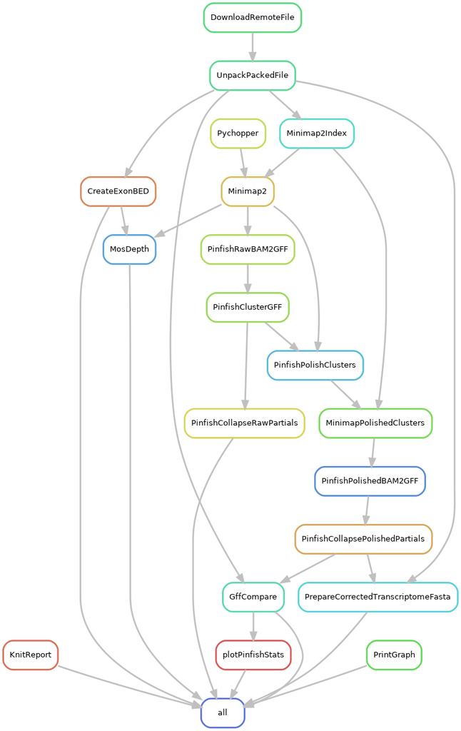

# 12 Tool references

A list of the R packages used to create this report is shown next.

```
R version 3.6.1 (2019-07-05)
Platform: x86_64-pc-linux-gnu (64-bit)
Running under: Ubuntu 16.04.6 LTS

Matrix products: default
BLAS:   /usr/lib/libblas/libblas.so.3.6.0
LAPACK: /usr/lib/lapack/liblapack.so.3.6.0

attached base packages:
[1] stats4    parallel  stats     graphics  grDevices utils     datasets  methods   base

loaded via a namespace (and not attached):
 [1] bitops_1.0-6           bit64_0.9-7            webshot_0.5.1          httr_1.4.1
 [5] tools_3.6.1            backports_1.1.4        R6_2.4.0               DBI_1.0.0
 [9] lazyeval_0.2.2         colorspace_1.4-1       withr_2.1.2            tidyselect_0.2.5
[13] curl_4.0               bit_1.1-14             compiler_3.6.1         chron_2.3-54
[17] rvest_0.3.4            xml2_1.2.2             labeling_0.3           scales_1.0.0
[21] askpass_1.1            rmarkdown_1.15         pkgconfig_2.0.2        htmltools_0.3.6
[25] highr_0.8              rlang_0.4.0            rstudioapi_0.10        RSQLite_2.1.2
[29] shiny_1.3.2            jsonlite_1.6           hwriter_1.3.2          RCurl_1.95-4.12
[33] magrittr_1.5           GenomeInfoDbData_1.2.1 Matrix_1.2-17          Rcpp_1.0.2
[37] munsell_0.5.0          proto_1.0.0            sqldf_0.4-11           stringi_1.4.3
[41] RJSONIO_1.3-1.2        zlibbioc_1.30.0        plyr_1.8.4             grid_3.6.1
[45] blob_1.2.0             promises_1.0.1         crayon_1.3.4           miniUI_0.1.1.1
[49] lattice_0.20-38        hms_0.5.1              zeallot_0.1.0          pillar_1.4.2
[53] igraph_1.2.4.1         reshape2_1.4.3         XML_3.98-1.20          glue_1.3.1
[57] evaluate_0.14          qpdf_1.1               latticeExtra_0.6-28    httpuv_1.5.1
[61] png_0.1-7              vctrs_0.2.0            gtable_0.3.0           purrr_0.3.2
[65] assertthat_0.2.1       gsubfn_0.7             ggExtra_0.9            xfun_0.9
[69] mime_0.7               xtable_1.8-4           later_0.8.0            viridisLite_0.3.0
[73] tibble_2.1.3           memoise_1.1.0
```

It is also worth recording the versions of the software that have been used for the analysis itself.

```
 [1] "conda 4.7.11"
 [2] "# packages in environment at /opt/biotools/miniconda3/envs/pinfish_3.6:"
 [3] "#"
 [4] "# Name                    Version                   Build  Channel"
 [5] "bioconductor-rsamtools    2.0.0             r36he1b5a44_1    bioconda"
 [6] "gffcompare                0.11.2               h6bb024c_0    bioconda"
 [7] "gffread                   0.11.4               hdbcaa40_0    bioconda"
 [8] "igv                       2.4.9                         1    bioconda"
 [9] "minimap2                  2.17                 h84994c4_0    bioconda"
[10] "mosdepth                  0.2.5                hb763d49_0    bioconda"
[11] "openjdk                   10.0.2            h14c3975_1015    conda-forge"
[12] "pinfish                   190125                b6f3c06_3    sagrudd"
[13] "pychopper                 0.6.1                     dev_0    <develop>"
[14] "r-rstudioapi              0.10              r36h6115d3f_0  "
[15] "racon                     1.3.2                h9b26653_1    sagrudd"
[16] "rstudio                   1.1.456              h6bb024c_1    r"
[17] "samtools                  1.9                 h8571acd_11    bioconda"
[18] "snakemake-minimal         5.2.4                    py36_0    bioconda"
```

last edit: Fri Aug 30 15:03:28 2019

[figure not shown]

more at **http://www.nucleomics.be**

# References and citations

*Integrative Genomics Viewer (Igv)*. 2018. Broad Institute, and the Regents of the University of California. http://www.broadinstitute.org/igv.

Köster, Johannes, and Sven Rahmann. 2012. “Snakemake—a Scalable Bioinformatics Workflow Engine.” *Bioinformatics* 28 (19): 2520–2. https://doi.org/10.1093/bioinformatics/bts480.

Li, Heng. 2018. “Minimap2: Pairwise Alignment for Nucleotide Sequences.” *Bioinformatics* 34 (18): 3094–3100. https://doi.org/10.1093/bioinformatics/bty191.

Morgan, Martin, Michael Lawrence, and Simon Anders. 2018. *ShortRead: FASTQ Input and Manipulation*.

Smith, Richard N., J. Aleksic, Daniela Butano, Adrian Carr, Sergio Contrino, Hu Fengyuan, M. Lyne, et al. 2012. “InterMine: A Flexible Data Warehouse System for the Integration and Analysis of Heterogeneous Biological Data.” *Bioinformatics* 28 (23): 3163–5.

Vaser, Robert, Ivan Sović, Niranjan Nagarajan, and Mile Šikić. 2017. “Fast and accurate de novo genome assembly from long uncorrected reads.” *Genome Research* 27 (5). Cold Spring Harbor Laboratory Press: 737–46. https://doi.org/10.1101/gr.214270.116.